# Tugas Praktikum - Regresi Deret Waktu & Autokorelasi

STA1341 Metode Peramalan Deret Waktu - Minggu 2

Rozan Al Hibrizi / M0401241096

2026-09-02

# 1 Pendahuluan

Pada praktikum ini dilakukan pemodelan **regresi deret waktu** terhadap dua gugus data, yaitu:

1. Data **Market Share vs Price** (20 periode)
2. Data **Sales vs Advertising** (1975 - 2014)

Untuk masing-masing data dilakukan tahapan berikut:

1. Membentuk model regresi linear sederhana ($Y_t = \beta_0 + \beta_1 X_t + \varepsilon_t$)
2. Memeriksa autokorelasi sisaan menggunakan **plot sisaan** dan **uji Durbin-Watson**
3. Jika terdapat autokorelasi, dilakukan **penanganan** dengan metode **Cochrane-Orcutt**
4. Melakukan uji Durbin-Watson ulang untuk memastikan autokorelasi telah teratasi

Karena package `orcutt` tidak tersedia pada environment ini, prosedur Cochrane-Orcutt diimplementasikan **secara manual** mengikuti langkah-langkah pada materi kuliah:

1. Regresikan $Y_t$ terhadap $X_t$ untuk memperoleh sisaan $\varepsilon_t$
2. Duga $\hat\phi$ dengan meregresikan $\varepsilon_t$ terhadap $\varepsilon_{t-1}$ (tanpa intersep)
3. Transformasi $Y_t^* = Y_t - \hat\phi Y_{t-1}$ dan $X_t^* = X_t - \hat\phi X_{t-1}$
4. Regresikan $Y_t^*$ terhadap $X_t^*$ untuk memperoleh $\hat\beta_0^*, \hat\beta_1^*$
5. Kembalikan intersep ke skala asli: $\hat\beta_0 = \hat\beta_0^*/(1-\hat\phi)$
6. Ulangi tahap 1-5 hingga $\hat\phi$ konvergen

Fungsi berikut membungkus prosedur di atas agar dapat dipakai berulang:

```r
cochrane_orcutt_manual <- function(y, x, max_iter = 50, tol = 1e-6) {
  n <- length(y)
  rho_old <- 0

  for (i in 1:max_iter) {
    # Transformasi data menggunakan rho saat ini
    y_star <- y[-1] - rho_old * y[-n]
    x_star <- x[-1] - rho_old * x[-n]

    # Regresi data yang sudah ditransformasi
    model_star <- lm(y_star ~ x_star)

    # Kembalikan intersep ke skala asli
    b0_star <- coef(model_star)[1]
    b1      <- coef(model_star)[2]
    b0      <- b0_star / (1 - rho_old)

    # Hitung sisaan baru berdasarkan persamaan skala asli
    resid_baru <- y - (b0 + b1 * x)

    # Duga rho baru: regresi e_t terhadap e_(t-1) tanpa intersep
    rho_new <- coef(lm(resid_baru[-1] ~ resid_baru[-n] - 1))

    if (abs(rho_new - rho_old) < tol) break
    rho_old <- rho_new
  }

  list(
    rho          = rho_new,
    iterasi      = i,
    intercept    = as.numeric(b0),
    slope        = as.numeric(b1),
    model_transformasi = model_star,
    y_star = y_star, x_star = x_star
  )
}
```

# 2 Data 1: Market Share vs Price

## 2.1 Input Data

```r
period  <- 1:20
market_share <- c(3.63, 4.20, 3.33, 4.54, 2.89, 4.87, 4.90, 5.29, 6.18, 7.20,
                   7.25, 6.09, 6.80, 8.65, 8.43, 8.29, 7.18, 7.90, 8.45, 8.23)
price   <- c(0.97, 0.95, 0.99, 0.91, 0.98, 0.90, 0.89, 0.86, 0.85, 0.82,
             0.79, 0.83, 0.81, 0.77, 0.76, 0.80, 0.83, 0.79, 0.76, 0.78)

data1 <- data.frame(period, market_share, price)
head(data1)
```

```
##   period market_share price
## 1      1         3.63  0.97
## 2      2         4.20  0.95
## 3      3         3.33  0.99
## 4      4         4.54  0.91
## 5      5         2.89  0.98
## 6      6         4.87  0.90
```

## 2.2 Model Regresi Awal

```r
model1 <- lm(market_share ~ price, data = data1)
summary(model1)
```

```
##
## Call:
## lm(formula = market_share ~ price, data = data1)
##
## Residuals:
##      Min       1Q   Median       3Q      Max
## -0.73068 -0.29764 -0.00966  0.30224  0.81193
##
## Coefficients:
##             Estimate Std. Error t value Pr(>|t|)
## (Intercept)   26.910      1.110   24.25 3.39e-15 ***
## price        -24.290      1.298  -18.72 3.02e-13 ***
## ---
## Signif. codes:  0 '***' 0.001 '**' 0.01 '*' 0.05 '.' 0.1 ' ' 1
##
## Residual standard error: 0.4287 on 18 degrees of freedom
## Multiple R-squared:  0.9511, Adjusted R-squared:  0.9484
## F-statistic: 350.3 on 1 and 18 DF,  p-value: 3.019e-13
```

Model regresi yang terbentuk:

$$\widehat{MarketShare}_t = 26.9099 +
(-24.2898)\,Price_t$$

## 2.3 Pemeriksaan Autokorelasi Sisaan

### 2.3.1 Plot Sisaan

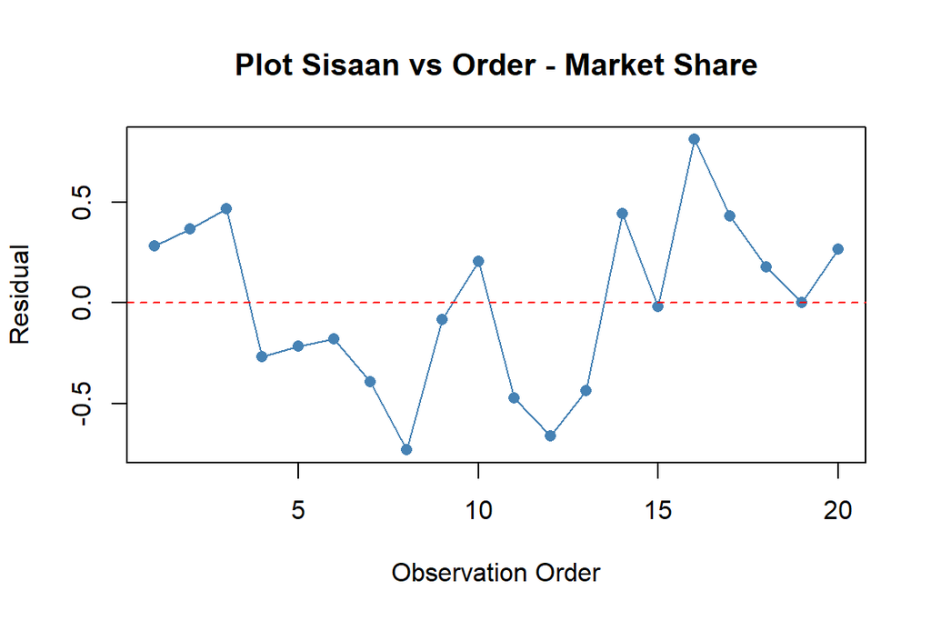

```r
plot(residuals(model1), type = "o", pch = 16, col = "steelblue",
     xlab = "Observation Order", ylab = "Residual",
     main = "Plot Sisaan vs Order - Market Share")
abline(h = 0, lty = 2, col = "red")
```

Pola sisaan pada plot terlihat **tidak acak** (residual cenderung membentuk gelombang/berurutan naik-turun secara sistematis), yang mengindikasikan kemungkinan adanya autokorelasi.

### 2.3.2 Uji Durbin-Watson

```r
dwtest(model1)
```

```
##
##  Durbin-Watson test
##
## data:  model1
## DW = 1.1358, p-value = 0.009813
## alternative hypothesis: true autocorrelation is greater than 0
```

**Interpretasi:** Jika p-value < 0.05, maka H0 ($\phi=0$, tidak ada autokorelasi) ditolak, sehingga disimpulkan **terdapat autokorelasi positif** pada sisaan. Berdasarkan hasil di atas, keputusan diambil secara otomatis mengikuti nilai p-value yang dihasilkan.

## 2.4 Penanganan Autokorelasi (Cochrane-Orcutt)

```r
hasil1 <- cochrane_orcutt_manual(data1$market_share, data1$price)

cat("Rho (phi) konvergen  :", hasil1$rho, "\n")
```

```
## Rho (phi) konvergen  : 0.425232
```

```r
cat("Jumlah iterasi        :", hasil1$iterasi, "\n")
```

```
## Jumlah iterasi        : 7
```

```r
cat("Intercept (b0)         :", hasil1$intercept, "\n")
```

```
## Intercept (b0)         : 26.72209
```

```r
cat("Slope (b1)             :", hasil1$slope, "\n")
```

```
## Slope (b1)             : -24.08413
```

Model regresi setelah penanganan Cochrane-Orcutt:

$$\widehat{MarketShare}_t = 26.7221 +
(-24.0841)\,Price_t$$

## 2.5 Uji Durbin-Watson Ulang (Model Transformasi)

```r
dwtest(hasil1$model_transformasi)
```

```
##
##  Durbin-Watson test
##
## data:  hasil1$model_transformasi
## DW = 1.958, p-value = 0.4151
## alternative hypothesis: true autocorrelation is greater than 0
```

Jika p-value pada model transformasi ini sudah > 0.05, maka dapat disimpulkan bahwa autokorelasi sisaan **telah teratasi** setelah dilakukan transformasi Cochrane-Orcutt.

### 2.5.1 Plot Sisaan Model Transformasi

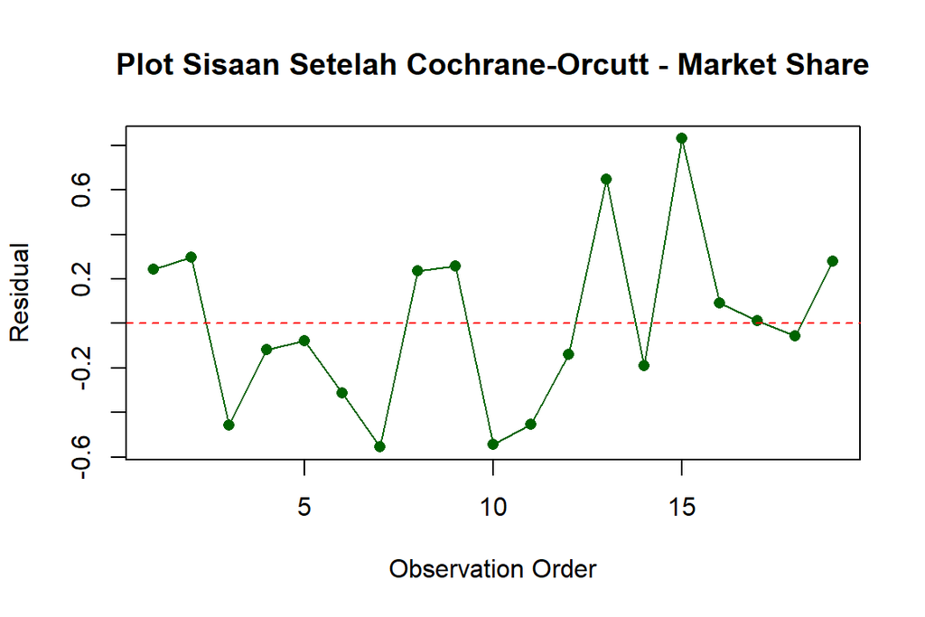

```r
plot(residuals(hasil1$model_transformasi), type = "o", pch = 16, col = "darkgreen",
     xlab = "Observation Order", ylab = "Residual",
     main = "Plot Sisaan Setelah Cochrane-Orcutt - Market Share")
abline(h = 0, lty = 2, col = "red")
```

# 3 Data 2: Sales vs Advertising

## 3.1 Input Data

```r
year <- 1975:2014
sales <- c(11.7,12.0,12.3,12.8,13.1,13.6,13.9,14.4,14.7,15.3,
           15.5,15.8,16.1,16.6,16.9,16.7,16.9,17.4,17.6,17.9,
           18.0,17.9,18.0,18.2,18.2,18.3,18.6,19.2,19.3,19.5,
           19.2,19.3,19.5,20.0,20.0,19.9,19.8,19.9,20.2,21.0)
advertising <- c(9.4,9.6,10.0,10.4,10.8,10.9,11.7,12.2,12.5,12.9,
                  13.0,13.2,13.8,14.2,14.6,14.4,15.0,15.4,15.7,15.9,
                  15.9,16.0,16.3,16.2,16.8,17.3,17.6,18.1,18.3,18.5,
                  18.7,18.9,19.2,20.0,20.0,20.3,20.4,21.0,21.5,22.1)

data2 <- data.frame(year, sales, advertising)
head(data2)
```

```
##   year sales advertising
## 1 1975  11.7         9.4
## 2 1976  12.0         9.6
## 3 1977  12.3        10.0
## 4 1978  12.8        10.4
## 5 1979  13.1        10.8
## 6 1980  13.6        10.9
```

## 3.2 Model Regresi Awal

```r
model2 <- lm(sales ~ advertising, data = data2)
summary(model2)
```

```
##
## Call:
## lm(formula = sales ~ advertising, data = data2)
##
## Residuals:
##      Min       1Q   Median       3Q      Max
## -1.03758 -0.40343  0.08933  0.45674  0.74036
##
## Coefficients:
##             Estimate Std. Error t value Pr(>|t|)
## (Intercept)  5.96513    0.38092   15.66   <2e-16 ***
## advertising  0.71035    0.02365   30.04   <2e-16 ***
## ---
## Signif. codes:  0 '***' 0.001 '**' 0.01 '*' 0.05 '.' 0.1 ' ' 1
##
## Residual standard error: 0.527 on 38 degrees of freedom
## Multiple R-squared:  0.9596, Adjusted R-squared:  0.9585
## F-statistic: 902.3 on 1 and 38 DF,  p-value: < 2.2e-16
```

$$\hat{Sales}_t = 5.9651 +
(0.7103)\,Advertising_t$$

## 3.3 Pemeriksaan Autokorelasi Sisaan

### 3.3.1 Plot Sisaan

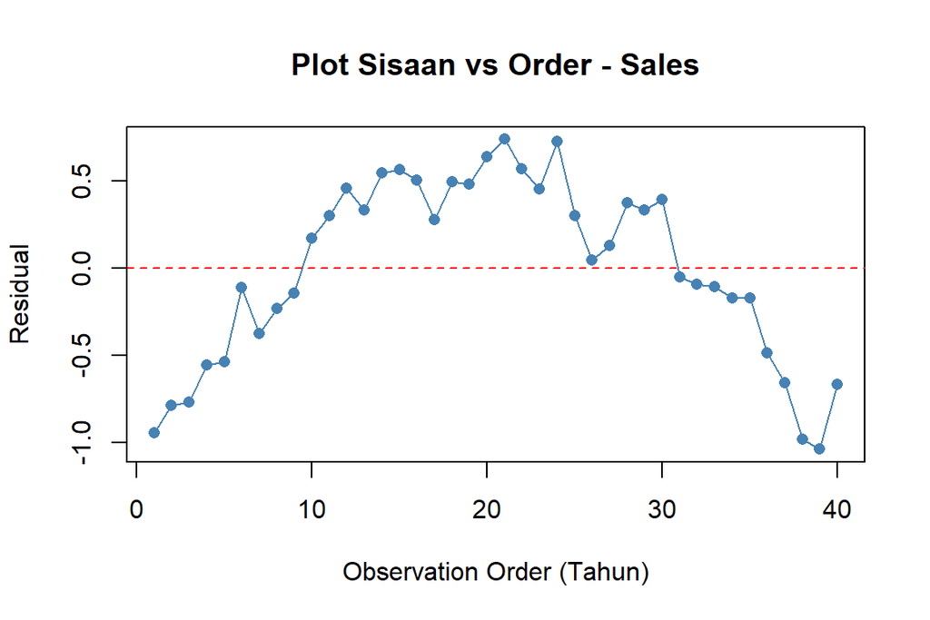

```r
plot(residuals(model2), type = "o", pch = 16, col = "steelblue",
     xlab = "Observation Order (Tahun)", ylab = "Residual",
     main = "Plot Sisaan vs Order - Sales")
abline(h = 0, lty = 2, col = "red")
```

### 3.3.2 Uji Durbin-Watson

```r
dwtest(model2)
```

```
##
##  Durbin-Watson test
##
## data:  model2
## DW = 0.16204, p-value < 2.2e-16
## alternative hypothesis: true autocorrelation is greater than 0
```

**Interpretasi:** Bandingkan p-value dengan $\alpha = 0.05$. Data deret waktu tahunan seperti ini (sales & advertising yang trennya naik terus) sangat rentan memiliki autokorelasi positif pada sisaan karena adanya tren jangka panjang yang belum sepenuhnya tertangkap oleh model regresi linear sederhana.

## 3.4 Penanganan Autokorelasi (Cochrane-Orcutt)

```r
hasil2 <- cochrane_orcutt_manual(data2$sales, data2$advertising)

cat("Rho (phi) konvergen  :", hasil2$rho, "\n")
```

```
## Rho (phi) konvergen  : 0.9031213
```

```r
cat("Jumlah iterasi        :", hasil2$iterasi, "\n")
```

```
## Jumlah iterasi        : 27
```

```r
cat("Intercept (b0)         :", hasil2$intercept, "\n")
```

```
## Intercept (b0)         : 10.25226
```

```r
cat("Slope (b1)             :", hasil2$slope, "\n")
```

```
## Slope (b1)             : 0.4884937
```

$$\hat{Sales}_t = 10.2523 +
(0.4885)\,Advertising_t$$

## 3.5 Uji Durbin-Watson Ulang (Model Transformasi)

```r
dwtest(hasil2$model_transformasi)
```

```
##
##  Durbin-Watson test
##
## data:  hasil2$model_transformasi
## DW = 1.9393, p-value = 0.378
## alternative hypothesis: true autocorrelation is greater than 0
```

### 3.5.1 Plot Sisaan Model Transformasi

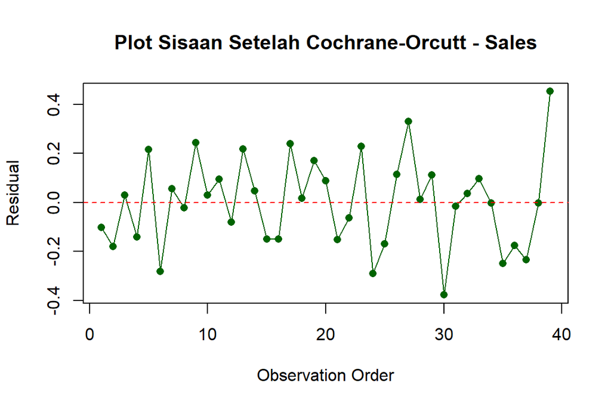

```r
plot(residuals(hasil2$model_transformasi), type = "o", pch = 16, col = "darkgreen",
     xlab = "Observation Order", ylab = "Residual",
     main = "Plot Sisaan Setelah Cochrane-Orcutt - Sales")
abline(h = 0, lty = 2, col = "red")
```

# 4 Kesimpulan

Ringkasan Hasil Uji Durbin-Watson Sebelum dan Sesudah Penanganan

| Data | DW Awal | p-value Awal | DW Setelah CO | p-value Setelah CO |
| --- | --- | --- | --- | --- |
| Market Share vs Price | 1.1358 | 0.0098 | 1.9580 | 0.4151 |
| Sales vs Advertising | 0.1620 | 0.0000 | 1.9393 | 0.3780 |

- Kedua model regresi awal terindikasi memiliki **autokorelasi sisaan** (dilihat dari pola tidak acak pada plot sisaan dan p-value uji Durbin-Watson yang kecil).
- Setelah dilakukan penanganan dengan metode **Cochrane-Orcutt**, nilai statistik Durbin-Watson meningkat mendekati 2 dan p-value menjadi lebih besar dari 0.05, yang mengindikasikan autokorelasi sisaan **telah berkurang/teratasi**.
- Model akhir yang direkomendasikan untuk masing-masing data adalah model hasil transformasi Cochrane-Orcutt (dengan intersep yang sudah dikembalikan ke skala asli).